# alpha_diversity_and_correlation

Goal: track Alpha Diversity and Proportionality over samples and establish sample ordering

# Installation

```r
# devtools::install_github("tpq/propr")
# install.packages('ggdendro')
```

```r
# devtools::install_github("jrnold/ggthemes")
# install.packages("ggthemes") # has tableau_tableau20 color palette
```

# Loading Required Packages

```r
library("ggplot2"); packageVersion("ggplot2") # plotting
```

```
[1] ‘3.3.5’
```

```r
library("tidyverse"); packageVersion("tidyverse") # util
```

```
[1] ‘1.3.1’
```

```r
library("dplyr"); packageVersion("dplyr") # util
```

```
[1] ‘1.0.7’
```

```r
library("phyloseq"); packageVersion("phyloseq") # data object
```

```
[1] ‘1.38.0’
```

```r
library("propr"); packageVersion("propr") # proportionality: compositional correlation
```

```
[1] ‘4.3.0’
```

# Initialization

```r
# ggplot2 package theme set
theme_set(theme_bw())

# control randomization
set.seed(42)

# save outputs
save_location = "../data/processed_biotic_49OTUs/"
```

# Aes

```r
# # color - days
# color_day = c(
#     "3" = "#B2E5EA", # lightest
#     "5" = "#00BAE7",
#     "7" = "#0E6FA0",
#     "10" = "#012652",
#     "20" = "#01091C"
#     )
#
# # color - growth.phase
# color_growth.phase = c(
#   "early" = "black",
#   "mid C:C" = "springgreen3",
#   "late C:C" = "springgreen4",
#   "perturbed G" = "steelblue1",
#   "mid G:C" = "steelblue3",
#   "late G:C" = "steelblue4",
#   "perturbed M" = "sienna1",
#   "mid M:C" = "sienna3",
#   "late M:C" = "sienna4"
#   )
#
# # shape - series
# shape_series = c(
#   "C0C" = 4,
#   "C" = 16,
#   "G" = 15,
#   "M" = 17
#   )
# # shape - carbon
# shape_carbon = c(
#   "original" = 4,
#   "cellulose" = 16,
#   "glucose" = 18,
#   "malate" = 15
# )
# # shape - transfer
# shape_transfer = c(
#     "C0C" = 4,
#     "1C" = 10,
#     "2C" = 16,
#     "1G" = 0,
#     "2G" = 12,
#     "3G" = 15,
#     "1M" = 5,
#     "2M" = 9,
#     "3M" = 18
#   )
# # shape - growth phase
# shape_growth.phase = c(
#   "early" = 1,
#   "mid C:C" = 16,
#   "late C:C" = 16,
#   "perturbed G" = 15,
#   "mid G:C" = 15,
#   "late G:C" = 15,
#   "perturbed M" = 17,
#   "mid M:C" = 17,
#   "late M:C" = 17
#   )
#
# # color - genus
```

## Extra Aes

```r
# # for 20 color palette
tableau_20_colors <- ggthemes::ggthemes_data[["tableau"]][["color-palettes"]][["regular"]][["Tableau 20"]]$value
```

```r
tableau_20_colors
```

```
 [1] "#4E79A7" "#A0CBE8" "#F28E2B" "#FFBE7D" "#59A14F" "#8CD17D" "#B6992D" "#F1CE63" "#499894" "#86BCB6" "#E15759" "#FF9D9A" "#79706E" "#BAB0AC" "#D37295" "#FABFD2" "#B07AA1" "#D4A6C8" "#9D7660" "#D7B5A6"
```

# Load Phyloseq Data Object

```r
ps <- readRDS(paste(save_location, "phyloseq.rds", sep=""))
ps
```

```
phyloseq-class experiment-level object
otu_table()   OTU Table:         [ 49 taxa and 74 samples ]
sample_data() Sample Data:       [ 74 samples by 7 sample variables ]
tax_table()   Taxonomy Table:    [ 49 taxa by 7 taxonomic ranks ]
```

```r
sample_data(ps)
```

```
Sample Data:        [74 samples by 7 sample variables]:
```

|  | series | day | replicate | experiment | RC | shdiv | numerical_day |
| --- | --- | --- | --- | --- | --- | --- | --- |
| D_011A | D | 11 | A | none | 97130 | 2.198627 | 11 |
| D_011B | D | 11 | B | none | 108420 | 2.473297 | 11 |
| D_003A | D | 3 | A | none | 99098 | 2.742455 | 3 |
| D_003B | D | 3 | B | none | 82085 | 2.600032 | 3 |
| D_005A | D | 5 | A | none | 126397 | 1.685470 | 5 |
| D_005B | D | 5 | B | none | 98060 | 1.702726 | 5 |
| D_007A | D | 7 | A | none | 114468 | 1.880626 | 7 |
| D_007B | D | 7 | B | none | 109292 | 1.824214 | 7 |
| D_start_200A | D_start | 200 | A | start 200 | 89310 | 1.734827 | 200 |
| D_start_200B | D_start | 200 | B | start 200 | 114611 | 1.613681 | 200 |

[output cut: 64 more lines]

```r
sample_meta <- data.frame(sample_data(ps))
sample_meta
```

|  | series | day | replicate | experiment | RC | shdiv | numerical_day |
| --- | --- | --- | --- | --- | --- | --- | --- |
| D_011A | D | 11 | A | none | 97130 | 2.198627 | 11 |
| D_011B | D | 11 | B | none | 108420 | 2.473297 | 11 |
| D_003A | D | 3 | A | none | 99098 | 2.742455 | 3 |
| D_003B | D | 3 | B | none | 82085 | 2.600032 | 3 |
| D_005A | D | 5 | A | none | 126397 | 1.685470 | 5 |
| D_005B | D | 5 | B | none | 98060 | 1.702726 | 5 |
| D_007A | D | 7 | A | none | 114468 | 1.880626 | 7 |
| D_007B | D | 7 | B | none | 109292 | 1.824214 | 7 |
| D_start_200A | D_start | 200 | A | start 200 | 89310 | 1.734827 | 200 |
| D_start_200B | D_start | 200 | B | start 200 | 114611 | 1.613681 | 200 |

[output cut: 64 more lines]

```r
# # make C0C part of C series
# sample_meta$series[1] <- "C"
# make variable to store each time point (tp)
sample_meta <- sample_meta %>%
  mutate(tp = paste(series, sprintf("%02d", numerical_day), sep="-"))
# reorder data frame
sample_meta <- sample_meta[with(sample_meta, order(series, numerical_day)),]
# make tp an ordered factor
sample_meta$tp <- factor(sample_meta$tp, levels = unique(sample_meta$tp))
# make variable to store tp_order (as numeric value)
tp_order_map <- 1:length(unique(sample_meta$tp))
names(tp_order_map) <- unique(sample_meta$tp)
sample_meta <- sample_meta %>%
  mutate(tp_order = tp_order_map[as.character(tp)])
# final sample_meta
sample_meta
```

|  | series | day | replicate | experiment | RC | shdiv | numerical_day | tp | tp_order |
| --- | --- | --- | --- | --- | --- | --- | --- | --- | --- |
| F_000D | F | 0 | D | none | 8721 | 3.102879 | 0 | F-00 | 1 |
| F_000A | F | 0 | A | none | 47411 | 1.720864 | 0 | F-00 | 1 |
| F_003D | F | 3 | D | none | 80391 | 2.090803 | 3 | F-03 | 2 |
| F_005D | F | 5 | D | none | 29167 | 2.323295 | 5 | F-05 | 3 |
| F_007D | F | 7 | D | none | 29946 | 2.324012 | 7 | F-07 | 4 |
| F_011D | F | 11 | D | none | 17800 | 3.010156 | 11 | F-11 | 5 |
| F_014D | F | 14 | D | none | 30909 | 2.499559 | 14 | F-14 | 6 |
| F_014E | F | 14 | E | none | 27340 | 2.563951 | 14 | F-14 | 6 |
| F_alien_000D | F_alien | 0 | D | new_Rubrivivax | 29555 | 3.202587 | 0 | F_alien-00 | 7 |
| F_alien_003D | F_alien | 3 | D | new_Rubrivivax | 20613 | 2.232936 | 3 | F_alien-03 | 8 |

[output cut: 64 more lines]

# Alpha Diversity

## ShDiv vs. RC

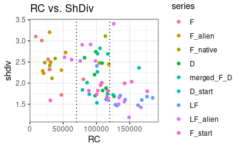

```r
ggplot(sample_meta, aes(x=RC, y=shdiv, colour=series)) +
  geom_point() +
  geom_vline(xintercept = 70000, linetype = "dotted") +
  geom_vline(xintercept = 120000, linetype = "dotted") +
  # scale_color_manual(values=color_growth.phase) +
  theme_set(theme_classic()) +
  ggtitle("RC vs. ShDiv")
```

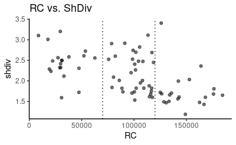

```r
ggplot(sample_meta, aes(x=RC, y=shdiv, alpha=0.3)) +
  geom_point(show.legend = FALSE) +
  geom_vline(xintercept = 70000, linetype = "dotted") +
  geom_vline(xintercept = 120000, linetype = "dotted") +
  theme_set(theme_classic()) +
  ggtitle("RC vs. ShDiv")
```

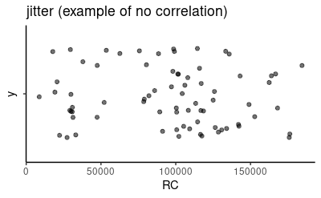

```r
ggplot(sample_meta, aes(x=RC, y="", alpha=0.3)) +
  geom_jitter(show.legend = FALSE, width = 0) +
  theme_set(theme_classic()) +
  ggtitle("jitter (example of no correlation)")
```

## ShDiv vs. Time Points

```r
sample_meta$tp
```

```
 [1] F-00          F-00          F-03          F-05          F-07          F-11          F-14          F-14          F_alien-00
[10] F_alien-03    F_alien-05    F_alien-07    F_alien-11    F_alien-14    F_alien-14    F_native-00   F_native-03   F_native-05
[19] F_native-07   F_native-14   F_native-14   D-03          D-03          D-05          D-05          D-07          D-07
[28] D-11          D-11          merged_F_D-04 merged_F_D-04 merged_F_D-04 merged_F_D-10 merged_F_D-10 merged_F_D-10 merged_F_D-15
[37] merged_F_D-15 merged_F_D-15 D_start-200   D_start-200   D_start-200   LF-00         LF-03         LF-03         LF-05
[46] LF-05         LF-07         LF-07         LF-11         LF-11         LF_alien-00   LF_alien-00   LF_alien-03   LF_alien-03
[55] LF_alien-03   LF_alien-05   LF_alien-05   LF_alien-05   LF_alien-07   LF_alien-07   LF_alien-07   LF_alien-11   LF_alien-11
[64] F_start-50    F_start-50    F_start-50    F_start-100   F_start-100   F_start-100   F_start-200   F_start-200   F_start-200
[73] F_start-200   F_start-200
38 Levels: F-00 F-03 F-05 F-07 F-11 F-14 F_alien-00 F_alien-03 F_alien-05 F_alien-07 F_alien-11 F_alien-14 F_native-00 ... F_start-200
```

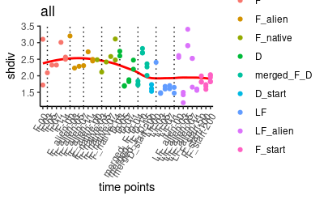

```r
sample_meta %>%
  ggplot(aes(x=tp_order, y=shdiv)) +
    geom_smooth(method = "loess", se = FALSE, colour="red") +
    # geom_smooth(method = lm, se = FALSE, linetype = "dashed") +
    geom_vline(xintercept = 2, linetype = "dotted") +
    geom_vline(xintercept = 7, linetype = "dotted") +
    geom_vline(xintercept = 10, linetype = "dotted") +
    geom_vline(xintercept = 14, linetype = "dotted") +
    geom_vline(xintercept = 18, linetype = "dotted") +
    geom_vline(xintercept = 22, linetype = "dotted") +
    geom_vline(xintercept = 26, linetype = "dotted") +
    geom_vline(xintercept = 30, linetype = "dotted") +
    geom_point(aes(x=tp_order, y=shdiv, colour=series)) +
    # scale_color_manual(values=color_growth.phase) +
    theme_set(theme_classic()) +
    theme(axis.text.x = element_text(angle = 60, hjust = 1)) +
    scale_x_discrete(name = "time points",
                     limits=unique(sample_meta$tp)) +
    ggtitle("all")
```

## Mid-Band ShDiv vs. Time Points

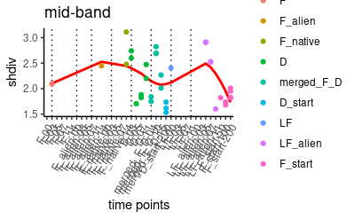

```r
sample_meta %>%
  filter(RC > 70000 & RC < 120000) %>%
  ggplot(aes(x=tp_order, y=shdiv)) +
    geom_smooth(method = "loess", se = FALSE, colour="red") +
    # geom_smooth(method = lm, se = FALSE, linetype = "dashed") +
    geom_vline(xintercept = 2, linetype = "dotted") +
    geom_vline(xintercept = 7, linetype = "dotted") +
    geom_vline(xintercept = 10, linetype = "dotted") +
    geom_vline(xintercept = 14, linetype = "dotted") +
    geom_vline(xintercept = 18, linetype = "dotted") +
    geom_vline(xintercept = 22, linetype = "dotted") +
    geom_vline(xintercept = 26, linetype = "dotted") +
    geom_vline(xintercept = 30, linetype = "dotted") +
    geom_point(aes(x=tp_order, y=shdiv, colour=series)) +
    # scale_color_manual(values=color_growth.phase) +
    theme_set(theme_classic()) +
    theme(axis.text.x = element_text(angle = 60, hjust = 1)) +
    scale_x_discrete(name = "time points",
                     limits=unique(sample_meta$tp)) +
    ggtitle("mid-band")
```

# Correlation (propr - rho)

```r
ps
```

```
phyloseq-class experiment-level object
otu_table()   OTU Table:         [ 49 taxa and 74 samples ]
sample_data() Sample Data:       [ 74 samples by 7 sample variables ]
tax_table()   Taxonomy Table:    [ 49 taxa by 7 taxonomic ranks ]
```

```r
(ps_clr <- microbiome::transform(ps, "clr"))
```

```
phyloseq-class experiment-level object
otu_table()   OTU Table:         [ 49 taxa and 74 samples ]
sample_data() Sample Data:       [ 74 samples by 7 sample variables ]
tax_table()   Taxonomy Table:    [ 49 taxa by 7 taxonomic ranks ]
```

## Calculate Proportionality, Indentify Cutoff

```r
counts <- t(as(otu_table(ps), "matrix"))
(pr <- propr(counts, # rows as samples, like it should be
            metric = "rho", # or "phi", "phs", "cor", "vlr"
            ivar = "clr", # or can use "iqlr" instead
            alpha = NA, # use to handle zeros
            p = 100)) # used by updateCutoffs
```

```
Alert: Replacing 0s with next smallest value.
Alert: Saving log-ratio transformed counts to @logratio.
Alert: Fixing permutations to active random seed.
Alert: Tabulating the presence of 0 counts.
Alert: Use '[' to index proportionality matrix.
Alert: Use 'updateCutoffs' to calculate FDR.
```

```
Not weighted and not alpha-transformed
@counts summary: 74 subjects by 49 features
@logratio summary: 74 subjects by 49 features
@matrix summary: 49 features by 49 features
@pairs summary: index with `[` method
@fdr summary: iterations
See ?propr for object methods
```

```r
# Choose the largest cutoff with an acceptable FDR.
updateCutoffs(pr,
              cutoff = seq(0, 1, .05), # cutoffs at which to estimate FDR
              ncores = 1) # parallelize here
```

```
Alert: Try parallelizing updateCutoffs with ncores > 1.
Alert: Estimating FDR for largely positive proportional pairs only.
```

```
|------------(25%)----------(50%)----------(75%)----------|
Not weighted and not alpha-transformed
@counts summary: 74 subjects by 49 features
@logratio summary: 74 subjects by 49 features
@matrix summary: 49 features by 49 features
@pairs summary: index with `[` method
@fdr summary: iterations
```

| cutoff | randcounts | truecounts | FDR |
| --- | --- | --- | --- |
| 0.00 | 499.31 | 541 | 0.9229390018 |
| 0.05 | 319.99 | 515 | 0.6213398058 |
| 0.10 | 180.26 | 474 | 0.3802953586 |
| 0.15 | 88.46 | 420 | 0.2106190476 |
| 0.20 | 37.37 | 382 | 0.0978272251 |
| 0.25 | 13.82 | 346 | 0.0399421965 |
| 0.30 | 4.07 | 307 | 0.0132573290 |
| 0.35 | 0.98 | 281 | 0.0034875445 |
| 0.40 | 0.23 | 266 | 0.0008646617 |
| 0.45 | 0.04 | 241 | 0.0001659751 |

[output cut: 11 more lines]

```
See ?propr for object methods
```

```r
# narrow down range to find FDR ~0.05
updateCutoffs(pr,
              cutoff = seq(0.25, 0.30, .01), # cutoffs at which to estimate FDR
              ncores = 1) # parallelize here
```

```
Alert: Try parallelizing updateCutoffs with ncores > 1.
Alert: Estimating FDR for largely positive proportional pairs only.
```

```
|------------(25%)----------(50%)----------(75%)----------|
Not weighted and not alpha-transformed
@counts summary: 74 subjects by 49 features
@logratio summary: 74 subjects by 49 features
@matrix summary: 49 features by 49 features
@pairs summary: index with `[` method
@fdr summary: iterations
```

| cutoff | randcounts | truecounts | FDR |
| --- | --- | --- | --- |
| 0.25 | 13.82 | 346 | 0.03994220 |
| 0.26 | 11.03 | 334 | 0.03302395 |
| 0.27 | 8.52 | 326 | 0.02613497 |
| 0.28 | 6.68 | 322 | 0.02074534 |
| 0.29 | 5.16 | 317 | 0.01627760 |
| 0.30 | 4.07 | 307 | 0.01325733 |

```
See ?propr for object methods
```

## Get Cluster Propr

- identify a highly proportional transcript module that happens to show differential abundance across the experimental groups
- take an unsupervised approach by hierarchically clustering the highly proportional feature pairs based on the matrix 1−|ρp|.
- when clustering, we call two features co-clustered if they belong to the cluster after cutting the dendrogram.

```r
# Parameters
CUTOFF = 0.29 # rho cutoff
N <- 12 # number of clusters
```

```r
# subsetting propr object to the @pairs slot
pr_best <- pr[">", CUTOFF]
pr_best@pairs
```

```
  [1]    2    8   10   16   20   25   26   27   30   33   34   35   44   45   46   48   57   59   60   65   69   74   75   76   79   82
 [27]   93   94   95   97  102  104  110  112  117  119  121  122  134  136  137  139  140  141  147  153  159  161  162  164  165  166
 [53]  168  170  171  183  186  188  189  190  194  196  202  205  208  211  233  234  235  236  243  254  257  260  266  281  282  283
 [79]  284  285  292  353  354  359  363  368  369  370  373  376  377  378  387  388  389  391  404  407  428  429  430  431  432  439
[105]  457  461  466  467  468  471  474  475  476  485  486  487  489  506  515  517  520  553  554  560  562  563  575  576  577  578
[131]  579  580  581  582  586  588  605  606  609  624  628  635  656  658  659  660  661  665  673  676  678  679  680  686  703  704
[157]  707  722  723  724  725  726  733  755  760  761  762  765  768  779  780  781  783  802  805  820  821  822  823  824  831  854
[183]  869  870  871  873  880  903  904  905  906  910  918  923  924  925  931  953  956  958  961  964  975  976  977  979 1003 1004
[209] 1016 1017 1018 1019 1021 1022 1023 1027 1029 1052 1053 1057 1070 1071 1072 1078 1102 1106 1109 1114 1119 1120 1121 1127 1155 1163
[235] 1168 1169 1170 1176 1202 1203 1206 1209 1220 1221 1222 1224 1252 1255 1258 1269 1270 1271 1273 1304 1307 1318 1319 1320 1322 1364
[261] 1365 1366 1372 1403 1404 1406 1407 1454 1465 1466 1467 1469 1502 1504 1505 1553 1554 1602 1603 1612 1613 1614 1616 1652 1663 1712
[287] 1752 1753 1754 1755 1756 1757 1758 1762 1764 1802 1803 1804 1811 1852 1853 1860 1902 1909 1958 2002 2003 2009 2052 2058 2107 2152
[313] 2153 2155 2202 2204 2253
```

```r
# pr_best <- simplify(pr_best)
```

Look at the prism and bokeh functions for visualizing the co-clustering of proportional features. These plots share some key similarities: * they are all “index-naive” * they identify the feature pairs where both constituents co-cluster (with the total number of clusters toggled by k). * they return a vector of cluster memberships for all features in the propr object.

The prism function plots the variance of the ratio of the log-ratio transformed feature pair (VLR) versus the sum of the individual variances of each log-ratio transformed feature (VLS). The ratio of the VLR to the VLS equals 1−ρ. As such, we use here seven rainbow colored lines to indicate where ρ=[.01, .05, .50, 0, 1.50, 1.95, 1.99], going from red to violet. A low VLR with a high VLS suggests that the feature pair remains in an equilibrium despite high variability among the individual features.

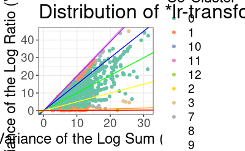

```r
pr_prism <- propr::prism(pr, k = N)
```

The bokeh function plots pairs across the individual variances of the constituent log-ratio transformed features. For clarity of visualization, this figure projects the data on a log-fold scale. Therefore, the highly variable co-clusters appear in the top-right of the figure while the lowly variable co-clusters appear in the bottom-left. Meanwhile, highly proportional pairs tend to aggregate around the y=x diagonal.

```
  OTU_1   OTU_2  OTU_21  OTU_23  OTU_27  OTU_34  OTU_38  OTU_39  OTU_44  OTU_51  OTU_52  OTU_58  OTU_77  OTU_94  OTU_95 OTU_124 OTU_129
      1       1       2       1       3       2       4       1       3       1       5       1       6       7       8       1       9
OTU_130 OTU_132 OTU_137 OTU_138 OTU_139 OTU_146 OTU_148 OTU_159 OTU_161 OTU_171 OTU_176 OTU_194 OTU_197 OTU_199 OTU_216 OTU_217 OTU_218
      9      10       1       1       3       7       7       7       7       7      10      11       1      11      11       1      12
OTU_219 OTU_236 OTU_238 OTU_251 OTU_254 OTU_264 OTU_279 OTU_280 OTU_290 OTU_291 OTU_298 OTU_299 OTU_324 OTU_325 OTU_336
     12       1       3       8       8       3       7       7       7       1       1       1       8       1      10
```

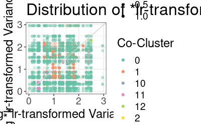

```r
bokeh(pr, k = N)
```

```r
unique(pr_prism)
```

```
 [1]  1  2  3  4  5  6  7  8  9 10 11 12
```

# Get list of higly correlated OTUs

```r
# create new data frame of OTU cluster membership
df_c <- data.frame(pr_prism)
colnames(df_c) <- c("cluster")
df_c$cluster <- as.factor(df_c$cluster)
# create new data frame of OTU taxonomy, OTU clr
df_c_tax <- as.data.frame(as.matrix(tax_table(ps)))
df_c_clr <- as.data.frame(as(otu_table(ps_clr), "matrix"))
# merge with data frame of cluster membership
df_c <- df_c %>%
  merge(df_c_tax, by.x=0, by.y=0, all = TRUE) %>%
  column_to_rownames("Row.names") %>%
  merge(df_c_clr, by.x=0, by.y=0) %>%
  column_to_rownames("Row.names")

# build list of valid OTUs (within-cluster pairwise rho > cutoff)
otu_c <- c()
otu_c_cluster_counts <- c()
for (x in 1:N) {
  subset_c <- rownames(filter(df_c, cluster == x))
  if ("AsIs" %in% class(subset_c)) {
    class(subset_c) <- class(subset_c)[-match("AsIs", class(subset_c))]
  }
  # get pairs with rho > cutoff AND both members in cluster n
  res_c <- getResults(pr,
             cutoff = CUTOFF, # minimum rho value
             include = subset_c,
             or = FALSE)
  # append valid OTUs (across both Partner and Pair)
  otu_union <- union(res_c$Partner, res_c$Pair)
  otu_c_cluster_counts <- c(otu_c_cluster_counts, length(otu_union))
  otu_c <- c(otu_c, otu_union)
}

# name counts of valid OTUs per cluster
names(otu_c_cluster_counts) <- 1:N
# only keep subset of valid OTUs
df_c <- df_c[otu_c, ]
# de-index OTU column
df_c <- cbind(OTU = rownames(df_c), df_c)
rownames(df_c) <- 1:nrow(df_c)
df_c
```

|  | OTU | cluster | kingdom | phylum | class | order | family | genus | species | D_011A | D_011B | D_003A | D_003B | D_005A | D_005B | D_007A | D_007B | D_start_200A | D_start_200B | D_start_200C | merged_F_D_004A | merged_F_D_010A | merged_F_D_015A | merged_F_D_004B | merged_F_D_010B | merged_F_D_015B | merged_F_D_004C | merged_F_D_010C | merged_F_D_015C | … |
| --- | --- | --- | --- | --- | --- | --- | --- | --- | --- | --- | --- | --- | --- | --- | --- | --- | --- | --- | --- | --- | --- | --- | --- | --- | --- | --- | --- | --- | --- | --- |
| 1 | OTU_325 | 1 | Bacteria | Spirochaetae | Spirochaetes | Spirochaetales | Spirochaetaceae | Spirochaeta | Unassigned | -0.12459521 | -0.3535255 | 1.2504232 | 0.5401023 | 1.3092633 | 1.0395055 | 0.7036824 | 0.7732723 | 2.0305043 | 2.2625015 | 2.0494616 | 0.16681402 | 1.2155754 | 2.02050531 | 1.00517424 | 1.14912554 | 2.35343363 | 0.68187471 | 1.1666485 | 1.01290183 | … |
| 2 | OTU_51 | 1 | Bacteria | Bacteroidetes | Sphingobacteriia | Sphingobacteriales | Unassigned | Unassigned | Unassigned | 4.36839409 | 4.7159378 | 2.8394693 | 3.4151372 | 2.7078856 | 3.0946083 | 3.4662558 | 3.0121747 | 2.2250342 | 2.5358388 | 2.4302987 | 1.86806357 | 4.0752604 | 3.70260770 | 2.19136505 | 4.03870323 | 3.50069959 | 2.29085682 | 4.3751566 | 3.93325046 | … |
| 3 | OTU_299 | 1 | Bacteria | Proteobacteria | Gammaproteobacteria | Enterobacteriales | Enterobacteriaceae | Raoultella | Unassigned | 1.67165546 | 2.0541470 | 4.0749946 | 3.6097219 | 2.8945264 | 3.2422813 | 1.9201445 | 2.4425176 | 3.6636603 | 3.6882326 | 3.5509278 | 2.98417038 | 2.5493570 | 2.78242498 | 2.78653584 | 2.54329925 | 3.16936064 | 3.20302814 | 2.4821774 | 2.64394890 | … |
| 4 | OTU_236 | 1 | Bacteria | Proteobacteria | Betaproteobacteria | Rhodocyclales | Rhodocyclaceae | Propionivibrio | Unassigned | -0.84732693 | -0.1612061 | -1.3981484 | -1.0848128 | -0.7504244 | -1.0813852 | -0.3303815 | -0.5397249 | -1.6122568 | -1.9334105 | -1.0670616 | 0.26173607 | -0.2037673 | -0.72727118 | -0.09530575 | -0.04466317 | -0.06654019 | -0.11713096 | 0.1443850 | 0.17988611 | … |
| 5 | OTU_137 | 1 | Bacteria | Proteobacteria | Alphaproteobacteria | Rhizobiales | Bradyrhizobiaceae | Unassigned | rhenobacensis | 1.72286221 | 0.5706326 | 2.1415285 | 1.9748154 | 1.8338116 | 1.1262298 | 1.6238987 | 1.3397748 | 1.4060671 | 1.6181293 | 1.4703269 | -0.16003144 | 0.7703784 | -0.01867145 | -0.37523265 | 0.45704599 | 0.42836811 | -0.06137128 | 0.2364880 | 0.59119517 | … |
| 6 | OTU_217 | 1 | Bacteria | Proteobacteria | Betaproteobacteria | Burkholderiales | Unassigned | Rhodoferax | Unassigned | 2.55484146 | 2.9660484 | 3.0522375 | 2.9122074 | 2.6552244 | 3.0295465 | 2.8473601 | 2.5611804 | 2.3002450 | 2.7064389 | 2.7840900 | 1.30812346 | 2.4868560 | 2.46618929 | 1.53019781 | 2.50711924 | 2.50136931 | 1.39495555 | 2.6237888 | 2.65732773 | … |
| 7 | OTU_298 | 1 | Bacteria | Proteobacteria | Gammaproteobacteria | Enterobacteriales | Enterobacteriaceae | Raoultella | Unassigned | 0.31633893 | 0.9413988 | 2.7241293 | 2.2372638 | 1.5709696 | 1.8412904 | 0.6468604 | 1.0321734 | 2.0980838 | 2.3201815 | 2.1834271 | 1.49866490 | 1.1293207 | 1.38427206 | 1.37452381 | 1.19454044 | 1.53044835 | 1.72258043 | 1.0216386 | 1.41927610 | … |
| 8 | OTU_2 | 1 | Bacteria | Acidobacteria | Unassigned | Unassigned | Unassigned | Unassigned | Unassigned | 2.15649736 | 2.3084308 | 1.3230642 | 1.3676421 | 0.8926974 | 0.9009066 | 1.5555924 | 1.3219644 | 0.1065935 | 0.5433278 | 0.2689420 | -1.42569392 | -1.8241102 | -3.05263332 | -0.76536556 | -1.34732830 | -2.70465853 | -0.45500905 | -2.0605242 | -2.81074553 | … |
| 9 | OTU_291 | 1 | Bacteria | Proteobacteria | Gammaproteobacteria | Enterobacteriales | Enterobacteriaceae | Enterobacter | Unassigned | 0.02238493 | 0.8502373 | 2.4532148 | 2.1663163 | 1.1761390 | 1.3581964 | 0.2148391 | 0.7732723 | 1.7432255 | 2.0049918 | 1.9490125 | 1.00594961 | 0.7980324 | 1.14444492 | 1.29959463 | 0.81153123 | 1.35360092 | 1.55072045 | 0.7224254 | 1.18414795 | … |
| 10 | OTU_197 | 1 | Bacteria | Proteobacteria | Betaproteobacteria | Burkholderiales | Unassigned | Albidiferax | Unassigned | 1.18147186 | 1.9360833 | 1.7605740 | 1.8409177 | 1.3092633 | 1.5994940 | 1.4737878 | 1.5098165 | 0.8293513 | 1.4829914 | 1.4617632 | -0.18803323 | 1.1901025 | 1.33086198 | 0.20391064 | 1.12562048 | 1.10940879 | 0.42887935 | 1.2337663 | 1.51890895 | … |

[output cut: 35 more lines]

```r
otu_c_cluster_counts
```

```
 1  2  3  4  5  6  7  8  9 10 11 12
16  2  4  0  0  0  9  4  2  3  3  2
```

```r
length(unique(df_c$kingdom))
```

```
[1] 1
```

```r
length(unique(df_c$phylum))
```

```
[1] 8
```

```r
length(unique(df_c$class))
```

```
[1] 13
```

```r
length(unique(df_c$order))
```

```
[1] 15
```

```r
length(unique(df_c$family))
```

```
[1] 14
```

```r
length(unique(df_c$genus))
```

```
[1] 21
```

```r
length(unique(df_c$species))
```

```
[1] 8
```

# Save to .csv

```r
# save
write.csv(df_c, paste(save_location, "propr.csv", sep=""), quote = FALSE)
```

### Plot, x=tp, real fit

```r
df_c_longer <- df_c %>%
  # pivot data so each row has x=sampleID, y=clr
  pivot_longer(phyloseq::sample_names(ps_clr),
               names_to = "sampleID",
               values_to = "clr") %>%
  # add variable series
  mutate(series = sample_meta[sampleID, "series"]) %>%
  # add variable growth.phase
  mutate(growth.phase = sample_meta[sampleID, "growth.phase"]) %>%
  # add variable tp
  mutate(tp = sample_meta[sampleID, "tp"]) %>%
  # add variable tp_order
  mutate(tp_order = sample_meta[sampleID, "tp_order"])
# establish that tp is an ordered factor
df_c_longer$tp <- factor(df_c_longer$tp, levels = unique(sample_meta$tp))
# reorder data frame
df_c_longer <- df_c_longer[with(df_c_longer, order(tp)),]
df_c_longer
```

| OTU | cluster | kingdom | phylum | class | order | family | genus | species | sampleID | clr | series | tp | tp_order |
| --- | --- | --- | --- | --- | --- | --- | --- | --- | --- | --- | --- | --- | --- |
| OTU_325 | 1 | Bacteria | Spirochaetae | Spirochaetes | Spirochaetales | Spirochaetaceae | Spirochaeta | Unassigned | F_000D | 1.184788700 | F | F-00 | 1 |
| OTU_325 | 1 | Bacteria | Spirochaetae | Spirochaetes | Spirochaetales | Spirochaetaceae | Spirochaeta | Unassigned | F_000A | -4.176124312 | F | F-00 | 1 |
| OTU_51 | 1 | Bacteria | Bacteroidetes | Sphingobacteriia | Sphingobacteriales | Unassigned | Unassigned | Unassigned | F_000D | -4.177442964 | F | F-00 | 1 |
| OTU_51 | 1 | Bacteria | Bacteroidetes | Sphingobacteriia | Sphingobacteriales | Unassigned | Unassigned | Unassigned | F_000A | -1.999990440 | F | F-00 | 1 |
| OTU_299 | 1 | Bacteria | Proteobacteria | Gammaproteobacteria | Enterobacteriales | Enterobacteriaceae | Raoultella | Unassigned | F_000D | -4.177442964 | F | F-00 | 1 |
| OTU_299 | 1 | Bacteria | Proteobacteria | Gammaproteobacteria | Enterobacteriales | Enterobacteriaceae | Raoultella | Unassigned | F_000A | -4.176124312 | F | F-00 | 1 |
| OTU_236 | 1 | Bacteria | Proteobacteria | Betaproteobacteria | Rhodocyclales | Rhodocyclaceae | Propionivibrio | Unassigned | F_000D | 3.154822569 | F | F-00 | 1 |
| OTU_236 | 1 | Bacteria | Proteobacteria | Betaproteobacteria | Rhodocyclales | Rhodocyclaceae | Propionivibrio | Unassigned | F_000A | 2.562874393 | F | F-00 | 1 |
| OTU_137 | 1 | Bacteria | Proteobacteria | Alphaproteobacteria | Rhizobiales | Bradyrhizobiaceae | Unassigned | rhenobacensis | F_000D | -4.177442964 | F | F-00 | 1 |
| OTU_137 | 1 | Bacteria | Proteobacteria | Alphaproteobacteria | Rhizobiales | Bradyrhizobiaceae | Unassigned | rhenobacensis | F_000A | -4.176124312 | F | F-00 | 1 |

[output cut: 990 more lines]

[figure not shown]

```r
# line plot, faceted by cluster, colored by taxrank
df_c_longer %>%
  ggplot(aes(x=tp, y=clr, group=OTU, color=genus), alpha=0.3) +
    geom_line() +
    # geom_vline(xintercept = "C-1-03", linetype = "dotted") +
    # geom_vline(xintercept = "C-2-03", linetype = "dotted") +
    # geom_vline(xintercept = "G-1-03", linetype = "dotted") +
    # geom_vline(xintercept = "G-2-03", linetype = "dotted") +
    # geom_vline(xintercept = "G-3-03", linetype = "dotted") +
    # geom_vline(xintercept = "M-1-03", linetype = "dotted") +
    # geom_vline(xintercept = "M-2-03", linetype = "dotted") +
    # geom_vline(xintercept = "M-3-03", linetype = "dotted") +
    # scale_colour_manual(values = tableau_20_colors) +
    guides(color=guide_legend(ncol=2)) +
    theme_set(theme_classic()) +
    theme(axis.text.x = element_text(angle = 60, hjust = 1)) +
    ggtitle("all") +
    facet_wrap( ~ cluster)
```

```r
# # line plot, faceted by cluster, colored by taxrank
# df_c_longer %>%
#   filter(series %in% c("F", "F_native", "F_alien")) %>%
#   ggplot(aes(x=tp, y=clr, group=OTU, color=genus), alpha=0.3) +
#     geom_line() +
#     geom_vline(xintercept = "C-1-03", linetype = "dotted") +
#     geom_vline(xintercept = "C-2-03", linetype = "dotted") +
#     # scale_colour_manual(values = tableau_20_colors) +
#     guides(color=guide_legend(ncol=2)) +
#     theme_set(theme_classic()) +
#     theme(axis.text.x = element_text(angle = 60, hjust = 1)) +
#     ggtitle("cellulose series") +
#     facet_wrap( ~ cluster)
#
# # line plot, faceted by cluster, colored by taxrank
# df_c_longer %>%
#   filter(series %in% c("D", "merge_F_D", "D_start")) %>%
#   ggplot(aes(x=tp, y=clr, group=OTU, color=genus), alpha=0.3) +
#     geom_line() +
#     geom_vline(xintercept = "G-1-03", linetype = "dotted") +
#     geom_vline(xintercept = "G-2-03", linetype = "dotted") +
#     geom_vline(xintercept = "G-3-03", linetype = "dotted") +
#     # scale_colour_manual(values = tableau_20_colors) +
#     guides(color=guide_legend(ncol=2)) +
#     theme_set(theme_classic()) +
#     theme(axis.text.x = element_text(angle = 60, hjust = 1)) +
#     ggtitle("glucose series") +
#     facet_wrap( ~ cluster)
#
# # line plot, faceted by cluster, colored by taxrank
# df_c_longer %>%
#   filter(series == "M") %>%
#   ggplot(aes(x=tp, y=clr, group=OTU, color=genus), alpha=0.3) +
#     geom_line() +
#     geom_vline(xintercept = "M-1-03", linetype = "dotted") +
#     geom_vline(xintercept = "M-2-03", linetype = "dotted") +
#     geom_vline(xintercept = "M-3-03", linetype = "dotted") +
#     # scale_colour_manual(values = tableau_20_colors) +
#     guides(color=guide_legend(ncol=2)) +
#     theme_set(theme_classic()) +
#     theme(axis.text.x = element_text(angle = 60, hjust = 1)) +
#     ggtitle("malate series") +
#     facet_wrap( ~ cluster)
```

### Plot (genus), x=tp_order, loess line of best fit

- less jagged
- loess lines require x_axis to be continuous

```r
tp_order_map
```

```
         F-00          F-03          F-05          F-07          F-11          F-14    F_alien-00    F_alien-03    F_alien-05
            1             2             3             4             5             6             7             8             9
   F_alien-07    F_alien-11    F_alien-14   F_native-00   F_native-03   F_native-05   F_native-07   F_native-14          D-03
           10            11            12            13            14            15            16            17            18
         D-05          D-07          D-11 merged_F_D-04 merged_F_D-10 merged_F_D-15   D_start-200         LF-00         LF-03
           19            20            21            22            23            24            25            26            27
        LF-05         LF-07         LF-11   LF_alien-00   LF_alien-03   LF_alien-05   LF_alien-07   LF_alien-11    F_start-50
           28            29            30            31            32            33            34            35            36
  F_start-100   F_start-200
           37            38
```

```r
# color_growth.phase
```

```
Warning: Removed 80 rows containing non-finite values (stat_smooth).
```

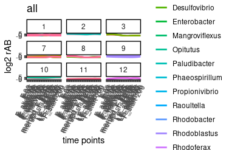

```r
df_c_longer %>%
  ggplot(aes(x=tp_order, y=clr, group=OTU, color=genus), alpha=0.3) +
    geom_smooth(method = "loess", se = FALSE, lwd=1.0) +
    # geom_point(alpha = 0.3) +
    # geom_vline(xintercept = 2, linetype = "solid", colour=color_growth.phase["mid C:C"]) +
    # geom_vline(xintercept = 7, linetype = "dotted") +
    # geom_vline(xintercept = 10, linetype = "solid", colour=color_growth.phase["perturbed G"]) +
    # geom_vline(xintercept = 14, linetype = "dotted") +
    # geom_vline(xintercept = 18, linetype = "dotted") +
    # geom_vline(xintercept = 22, linetype = "solid", colour=color_growth.phase["perturbed M"]) +
    # geom_vline(xintercept = 26, linetype = "dotted") +
    # geom_vline(xintercept = 30, linetype = "dotted") +
    # scale_colour_manual(values = tableau_20_colors) +
    guides(color=guide_legend(ncol=1)) +
    theme_set(theme_classic()) +
    theme(axis.text.x = element_text(angle = 60, hjust = 1)) +
    scale_y_continuous(name = "log2 rAB",
                       limits = c(-7, 7),
                       breaks=c(-5, 0, 5)
                       ) +
    scale_x_discrete(name = "time points",
                     limits=unique(df_c_longer$tp)) +
    ggtitle("all") +
    facet_wrap( ~ cluster)
```

```r
# df_c_longer %>%
#   filter(series == "C") %>%
#   ggplot(aes(x=tp_order, y=clr, group=OTU, color=genus), alpha=0.3) +
#     geom_smooth(method = "loess", se = FALSE) +
#     geom_vline(xintercept = 2, linetype = "solid", colour=color_growth.phase["mid C:C"]) +
#     geom_vline(xintercept = 7, linetype = "dotted") +
#     scale_colour_manual(values = tableau_20_colors) +
#     guides(color=guide_legend(ncol=2)) +
#     theme_set(theme_classic()) +
#     theme(axis.text.x = element_text(angle = 60, hjust = 1)) +
#     scale_y_continuous(name = "log2 rAB",
#                        limits = c(-7, 7),
#                        breaks=c(-5, 0, 5)
#                        ) +
#     scale_x_discrete(name = "time points",
#                      limits=1:10,
#                      labels=names(tp_order_map)[1:10]) +
#     ggtitle("cellulose series") +
#     facet_wrap( ~ cluster)
#
# df_c_longer %>%
#   filter(series == "G") %>%
#   ggplot(aes(x=tp_order, y=clr, group=OTU, color=genus), alpha=0.3) +
#     geom_smooth(method = "loess", se = FALSE) +
#     geom_vline(xintercept = 10, linetype = "dotted") +
#     geom_vline(xintercept = 14, linetype = "solid", colour=color_growth.phase["mid C:C"]) +
#     geom_vline(xintercept = 18, linetype = "dotted") +
#     scale_colour_manual(values = tableau_20_colors) +
#     guides(color=guide_legend(ncol=2)) +
#     theme_set(theme_classic()) +
#     theme(axis.text.x = element_text(angle = 60, hjust = 1)) +
#     scale_y_continuous(name = "log2 rAB",
#                        limits = c(-7, 7),
#                        breaks=c(-5, 0, 5)
#                        ) +
#     scale_x_discrete(name = "time points",
#                      limits=11:21,
#                      labels=names(tp_order_map)[11:21]) +
#     ggtitle("glucose series") +
#     facet_wrap( ~ cluster)
#
# df_c_longer %>%
#   filter(series == "M") %>%
#   ggplot(aes(x=tp_order, y=clr, group=OTU, color=genus), alpha=0.3) +
#     geom_smooth(method = "loess", se = FALSE) +
#     geom_vline(xintercept = 22, linetype = "dotted") +
#     geom_vline(xintercept = 26, linetype = "solid", colour=color_growth.phase["mid C:C"]) +
#     geom_vline(xintercept = 30, linetype = "dotted") +
#     scale_colour_manual(values = tableau_20_colors) +
#     guides(color=guide_legend(ncol=2)) +
#     theme_set(theme_classic()) +
#     theme(axis.text.x = element_text(angle = 60, hjust = 1)) +
#     scale_y_continuous(name = "log2 rAB",
#                        limits = c(-7, 7),
#                        breaks=c(-5, 0, 5)
#                        ) +
#     scale_x_discrete(name = "time points",
#                      limits=22:33,
#                      labels=names(tp_order_map)[22:33]) +
#     ggtitle("malate series") +
#     facet_wrap( ~ cluster)
```

### Plot (family) x=tp_order, loess line of best fit

[figure not shown]

```r
df_c_longer %>%
  ggplot(aes(x=tp_order, y=clr, group=OTU, color=family), alpha=0.3) +
    geom_smooth(method = "loess", se = FALSE) +
    # geom_vline(xintercept = 2, linetype = "dotted") +
    # geom_vline(xintercept = 7, linetype = "dotted") +
    # geom_vline(xintercept = 10, linetype = "dotted") +
    # geom_vline(xintercept = 14, linetype = "dotted") +
    # geom_vline(xintercept = 18, linetype = "dotted") +
    # geom_vline(xintercept = 22, linetype = "dotted") +
    # geom_vline(xintercept = 26, linetype = "dotted") +
    # geom_vline(xintercept = 30, linetype = "dotted") +
    # scale_colour_manual(values = tableau_20_colors) +
    guides(color=guide_legend(ncol=2)) +
    theme_set(theme_classic()) +
    theme(axis.text.x = element_text(angle = 60, hjust = 1)) +
    scale_y_continuous(name = "log2 rAB", breaks=c(0, 5, 10)) +
    scale_x_discrete(name = "time points",
                     limits=unique(df_c_longer$tp)) +
    ggtitle("all") +
    facet_wrap( ~ cluster)
```

```r
# df_c_longer %>%
#   filter(series == "C") %>%
#   ggplot(aes(x=tp_order, y=clr, group=OTU, color=family), alpha=0.3) +
#     geom_smooth(method = "loess", se = FALSE) +
#     geom_vline(xintercept = 2, linetype = "dotted") +
#     geom_vline(xintercept = 7, linetype = "dotted") +
#     scale_colour_manual(values = tableau_20_colors) +
#     guides(color=guide_legend(ncol=2)) +
#     theme_set(theme_classic()) +
#     theme(axis.text.x = element_text(angle = 60, hjust = 1)) +
#     scale_y_continuous(name = "log2 rAB", breaks=c(0, 5, 10)) +
#     scale_x_discrete(name = "time points",
#                      limits=1:10,
#                      labels=names(tp_order_map)[1:10]) +
#     ggtitle("cellulose series") +
#     facet_wrap( ~ cluster)
#
# df_c_longer %>%
#   filter(series == "G") %>%
#   ggplot(aes(x=tp_order, y=clr, group=OTU, color=family), alpha=0.3) +
#     geom_smooth(method = "loess", se = FALSE) +
#     geom_vline(xintercept = 10, linetype = "dotted") +
#     geom_vline(xintercept = 14, linetype = "dotted") +
#     geom_vline(xintercept = 18, linetype = "dotted") +
#     scale_colour_manual(values = tableau_20_colors) +
#     guides(color=guide_legend(ncol=2)) +
#     theme_set(theme_classic()) +
#     theme(axis.text.x = element_text(angle = 60, hjust = 1)) +
#     scale_y_continuous(name = "log2 rAB", breaks=c(0, 5, 10)) +
#     scale_x_discrete(name = "time points",
#                      limits=11:21,
#                      labels=names(tp_order_map)[11:21]) +
#     ggtitle("glucose series") +
#     facet_wrap( ~ cluster)
#
# df_c_longer %>%
#   filter(series == "M") %>%
#   ggplot(aes(x=tp_order, y=clr, group=OTU, color=family), alpha=0.3) +
#     geom_smooth(method = "loess", se = FALSE) +
#     geom_vline(xintercept = 22, linetype = "dotted") +
#     geom_vline(xintercept = 26, linetype = "dotted") +
#     geom_vline(xintercept = 30, linetype = "dotted") +
#     scale_colour_manual(values = tableau_20_colors) +
#     guides(color=guide_legend(ncol=2)) +
#     theme_set(theme_classic()) +
#     theme(axis.text.x = element_text(angle = 60, hjust = 1)) +
#     scale_y_continuous(name = "log2 rAB", breaks=c(0, 5, 10)) +
#     scale_x_discrete(name = "time points",
#                      limits=22:33,
#                      labels=names(tp_order_map)[22:33]) +
#     ggtitle("malate series") +
#     facet_wrap( ~ cluster)
```

### Plot corr per transfer

- Plot each prev day + transfer separately
- Facet by cluster

```r
unique(sample_meta$tp)
```

```r
# sample_meta$transfer
```

````r
# # new data frame
# df_d_longer <- df_c %>%
#   # pivot data so each row has x=sampleID, y=clr
#   pivot_longer(phyloseq::sample_names(ps_clr),
#                names_to = "sampleID",
#                values_to = "clr") %>%
#   # add variable transfer
#   mutate(transfer = sample_meta[sampleID, "transfer"]) %>%
#   # add variable tp
#   mutate(tp = sample_meta[sampleID, "tp"])
# # establish that tp is an ordered factor
# df_d_longer$tp <- factor(df_d_longer$tp, levels = unique(sample_meta$tp))
# # reorder data frame
# df_d_longer <- df_d_longer[with(df_d_longer, order(tp)),]
# df_d_longer
# ```
# ```{r}
# plot_corr_per_transfer <- function(df_d_longer, tp_order_map, title, legend_pos="right") {
#   df_d_longer %>%
#   # filter data
#   filter(tp %in% names(tp_order_map)) %>%
#   # numerical ordered x-axis
#   mutate(tp_order = tp_order_map[as.character(tp)]) %>%
#   # plot
#   ggplot(aes(x=tp_order, y=clr, group=OTU, color=genus), alpha=0.3) +
#     geom_point() +
#     geom_smooth(method = "loess", se = FALSE) +
#     geom_vline(xintercept = 2, linetype = "dotted", alpha=0.3) +
#     geom_hline(yintercept = 5, linetype = "dotted", alpha=0.3) +
#     geom_hline(yintercept = 0, linetype = "dashed", alpha=0.3) +
#     geom_hline(yintercept = -5, linetype = "dotted", alpha=0.3) +
#     theme_set(theme_classic()) +
#     scale_colour_manual(values = tableau_20_colors) +
#     theme(axis.text.x = element_text(angle = 60, hjust = 1),
#           legend.position = legend_pos) +
#     guides(color=guide_legend(ncol=2)) +
#     scale_y_continuous(name = "log2 rAB",
#                        limits = c(-7, 7),
#                        breaks=c(-5, 0, 5)) +
#     # x-axis labeling
#     scale_x_discrete(name = "time points",
#                      limits=1:length(tp_order_map),
#                      labels=names(tp_order_map)) +
#     facet_wrap( ~ cluster) +
#     ggtitle(title)
# }
````

```r
unique(df_d_longer$tp)
```

```r
# 1C
# plot_corr_per_transfer(df_d_longer,
#                        tp_order_map = c(
#                          "C-0-10" = 1,
#                          "C-1-03" = 2,
#                          "C-1-05" = 3,
#                          "C-1-07" = 4,
#                          "C-1-10" = 5,
#                          "C-1-20" = 6),
#                        title = "first transfer onto cellulose (1C)")
```

```r
# # 2C
# plot_corr_per_transfer(df_d_longer,
#                        tp_order_map = c(
#                          "C-1-20" = 1,
#                          "C-2-03" = 2,
#                          "C-2-05" = 3,
#                          "C-2-10" = 4),
#                        title = "second transfer onto cellulose (2C)")
```

```r
# # 1G
# plot_corr_per_transfer(df_d_longer,
#                        tp_order_map = c(
#                          "C-0-10" = 1,
#                          "G-1-03" = 2,
#                          "G-1-05" = 3,
#                          "G-1-07" = 4,
#                          "G-1-10" = 5),
#                        title = "perturbation transfer onto glucose (1G)")
```

```r
# # 2G
# plot_corr_per_transfer(df_d_longer,
#                        tp_order_map = c(
#                          "G-1-10" = 1,
#                          "G-2-03" = 2,
#                          "G-2-05" = 3,
#                          "G-2-07" = 4,
#                          "G-2-10" = 5),
#                        title = "first transfer back onto cellulose (2G)")
```

```r
# # 3G
# plot_corr_per_transfer(df_d_longer,
#                        tp_order_map = c(
#                          "G-2-10" = 1,
#                          "G-3-03" = 2,
#                          "G-3-05" = 3,
#                          "G-3-07" = 4,
#                          "G-3-10" = 5),
#                        title = "second transfer back onto cellulose (3G)")
```

```r
# # 1M
# plot_corr_per_transfer(df_d_longer,
#                        tp_order_map = c(
#                          "C-0-10" = 1,
#                          "M-1-03" = 2,
#                          "M-1-05" = 3,
#                          "M-1-07" = 4,
#                          "M-1-10" = 5),
#                        title = "perturbation transfer onto malate (1M)")
```

```r
# # 2M
# plot_corr_per_transfer(df_d_longer,
#                        tp_order_map = c(
#                          "M-1-10" = 1,
#                          "M-2-03" = 2,
#                          "M-2-05" = 3,
#                          "M-2-07" = 4,
#                          "M-2-10" = 5),
#                        title = "first transfer back onto cellulose (2M)")
```

```r
# # 3M
# plot_corr_per_transfer(df_d_longer,
#                        tp_order_map = c(
#                          "M-2-10" = 1,
#                          "M-3-03" = 2,
#                          "M-3-05" = 3,
#                          "M-3-07" = 4,
#                          "M-3-10" = 5),
#                        title = "second transfer back onto cellulose (3M)")
```